Revival

# Giselle

Choreography by *Patrice Bart* after *Coralli* and *Perrot*  
Music by *Adolphe Adam*

Love and betrayal – these are the great themes of *Giselle*, still one of the masterpieces of the Romantic ballet repertoire. The peasant girl Giselle not only loves dancing but also the nobleman Albrecht, who conceals his true identity from her. The young man courts her, even though he is already promised to another. When Giselle learns the truth, she loses her mind and dies. After her death, she is accepted into the community of the Wilis, supernatural beings who, like Giselle, died as brides before their weddings. Together with her companions, Giselle is condemned to seduce men into dancing until they die of exhaustion. Myrtha, the Queen of the Wilis, watches over this. Albrecht also comes into the forest to visit Giselle’s grave.

The desire to depict ghostly floating fairy beings on stage inspired choreographers in the 19th century, first in Paris, to literally elevate ballet en pointe. In mostly eerie settings, dancing elves and fairies roamed – in the ballet Giselle, it’s the dance-addicted Wilis around whom the libretto revolves. In homage to the grand French tradition from which he himself hails, Patrice Bart has created a version closely based on the original choreography by Jean Coralli and Jules Perrot, while also expressing the freshness and timelessness of the language of Romantic ballet. Peter Farmer’s stage design also reflects the aesthetics of this tradition. Patrice Bart‘s *Giselle* premiered at the Staatsoper Unter den Linden in 2000.

Dates

2024

Info

Staatsoper Unter den Linden

3:00 pm

2 h 20 min incl. one intermission

[Save the date](https://www.staatsballett-berlin.de/en/content/event/391.html)

12 – 82

Introduction 45 minutes before curtain.

Family performance

13.00

5

#### Family workshop

To prepare the visit to the opera, participants are introduced to the plot as well as important characters, and they also rehearse short dance scenes. Valid only in combination with a visit to a family performance.

##### Registration required

Tel: 030 34 384-166  
E-mail: contact@tanz-ist-klasse.de

### Cast29.9.

Choreography and Staging Patrice Bart  
Stage and Costume Design Peter Farmer  
Lighting Design Franz Peter David  
Dramaturgy Christiane Theobald  
Assistants to the Choreographer Claude de Vulpian  
Staged by Raffaella Renzi  
Bühnenbildassistenz Gerd Neubert  
Musical Direction [Marius Stravinsky](https://www.staatsballett-berlin.de/en/company/persons-detail/peid/marius-stravinsky/2000948.html)  
Staatskapelle Berlin  
Giselle [Danielle Muir](https://www.staatsballett-berlin.de/en/company/persons-detail/peid/danielle-muir/100087.html)  
Albrecht [David Soares](https://www.staatsballett-berlin.de/en/company/persons-detail/peid/david-soares/1000457.html)  
Myrtha, Königin der Wilis [Aurora Dickie](https://www.staatsballett-berlin.de/en/company/persons-detail/peid/aurora-dickie/1000192.html)  
Hilarion, ein Wildhüter [Alexei Orlenco](https://www.staatsballett-berlin.de/en/company/persons-detail/peid/alexei-orlenco/100070.html)

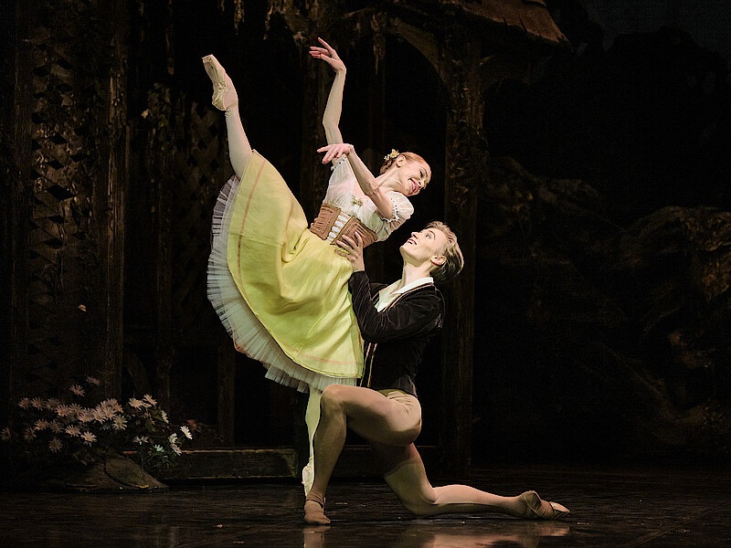

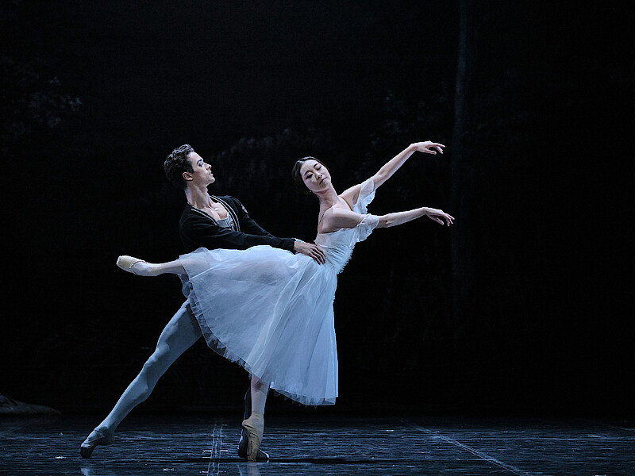

[figure not shown]

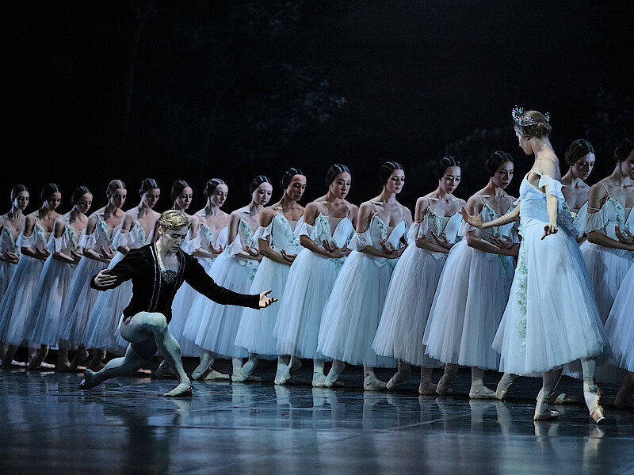

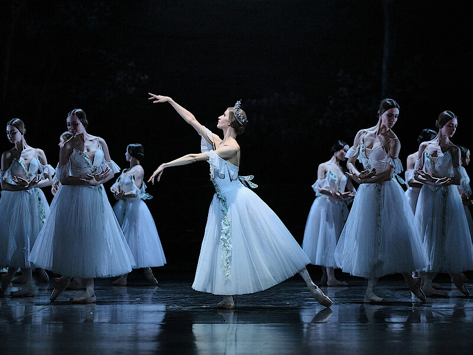

[figure not shown]

Photo: Admill Kuyler

### To Die Beautifully: An Aesthetics of Transience

Recommendations

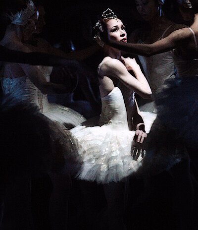

### Swan Lake

Ballett in zwei Akten  
Musik von *Peter I. Tschaikowsky*

Staatsoper Unter den Linden

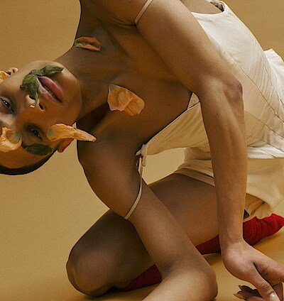

### A Midsummer Night's Dream

Ballett von *Edward Clug* nach William Shakespeare  
Musik von *Milko Lazar* (Auftragswerk)

Deutsche Oper Berlin

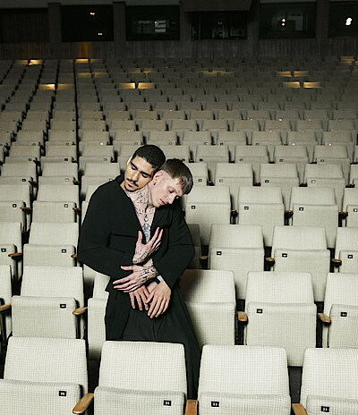

### Winterreise

Musik von *Hans Zender* nach *Franz Schuberts* Winterreise  
Choreographie und Inszenierung von *Christian Spuck*

Staatsoper Unter den Linden